# **Biostatistiques #1**

## **Découverte des commandes de base R et de ses fonctionnalités graphiques et statistiques**

I. Introduction to R

1. R as a calculator
2. Assigning data to R objects, using and reading them
3. Managing your session
4. Managing objects in your R Session
5. Saving your data, session, and history
6. Classes and types of R objects

II. Vectors

III. Dataframes

IV. Plots

V. Statistics

## Avant d'aller plus loin

**Attention:** Ne travaillez pas directement sur ce notebook pour ne pas le perdre. Dupliquez-le et renommez-le par exemple en ajoutant vos initiales et travaillez sur cette nouvelle copie. Pour ce faire, dans le panneau de gauche, faites un clic droit sur le fichier et sélectionnez "Duplicate". Puis, toujours dans la colonne de gauche, faites un clic droit sur cette copie et sélectionnez "rename" pour changer le nom. Ouvrez ensuite cette nouvelle version en double cliquant dessus. Vous êtes prêt(e) à démarrer!  
**N'oubliez pas de sauvegarder régulièrement votre notebook**: `Ctrl` + `S`. ou en cliquant sur l'icone 💾 en haut à gauche de votre notebook ou dans le Menu du JupyterLab "File puis "Save Notebook"!

**=> A propos de ce notebook jupyter**

Ce notebook jupyter notebook est en **R**, ce qui signifie que les commandes que vous entrerez dans les cellules de `Code` seront directement lues en R par le serveur.

## **I. Intoduction**

### **I.0 What is R ?**

R is available on this website: https://www.r-project.org

The language is:

- open-source
- available for Windows, Mac and Unix
- widely used in academia, finance, pharma, social sciences...

R includes a "core language" called `R base` with more than 3000 contributed packages. A package is a set of functions.

R can be used for:

1. data manipulation: import, format, edit, export
2. statistics
3. avdanced graphics

***Some useful links***

- Quick R: https://www.statmethods.net/index.html
- Emmanuel Paradis tutorial: [in French](https://cran.r-project.org/doc/contrib/Paradis-rdebuts_fr.pdf) or [in English](https://cran.r-project.org/doc/contrib/Paradis-rdebuts_en.pdf)
- R cheatsheet: https://rstudio.com/resources/cheatsheets/
- R style guide: https://google.github.io/styleguide/Rguide.html

### **I.1 - R as a calulator**

**Some very simple examples**

You can directly use R to perform mathematic operations with usual operators: `+`, `-`, `*` to multiply,`^` to raise to the power, `/` to divide, `%%` to get the modulo.

```r
# cell 1
2+2
```

4

```r
# cell 2
2-3
6/2
10/3
10%%3
```

-1

3

3.33333333333333

1

You can use built-in functions like `round()`,`log()`, `mean`...

```r
# cell 3
mean(c(1,2)) # we will see that we need to put concatenate different values with a c() first
exp(-2)
```

1.5

0.135335283236613

You can nest functions, in the following example, `exp()` is nested in `round()`

```r
# cell 4
round(exp(-2), 2)
```

0.14

For some functions, you need to enter several arguments. In the example below, we add the `base` argument for the `log()` function.

```r
# cell 5
log(100, base = 10) #we want to get the log of 100 in base 10
```

2

***Getting help on functions:***

To know which argument to use, it is recommanded to always look at the help of the functions. To do so, enter the name of the function after `?` or `help()` and the name of the function in the brackets. A help page will be displayed with different sections:

- description: what is the purpose of the function?
- usage: how is it used?
- arguments: which parameters are used by the function. Default values may be specified.
- details: technical description of the function
- value: type of the output returned by the function
- see also: similar functions in R
- source/references: not always
- example: concrete examples -> the best way to learn how it works!

```r
# cell 6
help(round)
```

| Round {base} | R Documentation |
| --- | --- |

Rounding of Numbers

Description

`ceiling` takes a single numeric argument `x` and returns a numeric vector containing the smallest integers not less than the corresponding elements of `x`.

`floor` takes a single numeric argument `x` and returns a numeric vector containing the largest integers not greater than the corresponding elements of `x`.

`trunc` takes a single numeric argument `x` and returns a numeric vector containing the integers formed by truncating the values in `x` toward `0`.

`round` rounds the values in its first argument to the specified number of decimal places (default 0). See ‘Details’ about “round to even” when rounding off a 5.

`signif` rounds the values in its first argument to the specified number of significant digits. Hence, for `numeric` `x`, `signif(x, dig)` is the same as `round(x, dig - ceiling(log10(abs(x))))`. For `complex` `x`, this is not the case, see the ‘Details’.

Usage

```
ceiling(x)
floor(x)
trunc(x, ...)

round(x, digits = 0)
signif(x, digits = 6)
```

Arguments

| `x` | a numeric vector. Or, for `round` and `signif`, a complex vector. |
| --- | --- |
| `digits` | integer indicating the number of decimal places (`round`) or significant digits (`signif`) to be used. Negative values are allowed (see ‘Details’). |
| `...` | arguments to be passed to methods. |

Details

These are generic functions: methods can be defined for them individually or via the `Math` group generic.

Note that for rounding off a 5, the IEC 60559 standard (see also ‘IEEE 754’) is expected to be used, ‘*go to the even digit*’. Therefore `round(0.5)` is `0` and `round(-1.5)` is `-2`. However, this is dependent on OS services and on representation error (since e.g. `0.15` is not represented exactly, the rounding rule applies to the represented number and not to the printed number, and so `round(0.15, 1)` could be either `0.1` or `0.2`).

Rounding to a negative number of digits means rounding to a power of ten, so for example `round(x, digits = -2)` rounds to the nearest hundred.

For `signif` the recognized values of `digits` are `1...22`, and non-missing values are rounded to the nearest integer in that range. Complex numbers are rounded to retain the specified number of digits in the larger of the components. Each element of the vector is rounded individually, unlike printing.

These are all primitive functions.

S4 methods

These are all (internally) S4 generic.

`ceiling`, `floor` and `trunc` are members of the `Math` group generic. As an S4 generic, `trunc` has only one argument.

`round` and `signif` are members of the `Math2` group generic.

Warning

The realities of computer arithmetic can cause unexpected results, especially with `floor` and `ceiling`. For example, we ‘know’ that `floor(log(x, base = 8))` for `x = 8` is `1`, but `0` has been seen on an **R** platform. It is normally necessary to use a tolerance.

Rounding to decimal digits in binary arithmetic is non-trivial (when `digits != 0`) and may be surprising. Be aware that most decimal fractions are *not* exactly representable in binary double precision. In **R** 4.0.0, the algorithm for `round(x, d)`, for *d > 0*, has been improved to *measure* and round “to nearest even”, contrary to earlier versions of **R** (or also to `sprintf()` or `format()` based rounding).

References

Becker, R. A., Chambers, J. M. and Wilks, A. R. (1988) *The New S Language*. Wadsworth & Brooks/Cole.

The ISO/IEC/IEEE 60559:2011 standard is available for money from https://www.iso.org.

The IEEE 754:2008 standard is more openly documented, e.g, at https://en.wikipedia.org/wiki/IEEE_754.

See Also

`as.integer`. Package round's `roundX()` for several versions or implementations of rounding, including some previous and the current **R** version (as `version = "3d.C"`).

Examples

```
round(.5 + -2:4) # IEEE / IEC rounding: -2  0  0  2  2  4  4
## (this is *good* behaviour -- do *NOT* report it as bug !)

( x1 <- seq(-2, 4, by = .5) )
round(x1) #-- IEEE / IEC rounding !
x1[trunc(x1) != floor(x1)]
x1[round(x1) != floor(x1 + .5)]
(non.int <- ceiling(x1) != floor(x1))

x2 <- pi * 100^(-1:3)
round(x2, 3)
signif(x2, 3)
```

[Package *base* version 4.1.3 ]

```r
# cell 7
?exp
```

| log {base} | R Documentation |
| --- | --- |

Logarithms and Exponentials

Description

`log` computes logarithms, by default natural logarithms, `log10` computes common (i.e., base 10) logarithms, and `log2` computes binary (i.e., base 2) logarithms. The general form `log(x, base)` computes logarithms with base `base`.

`log1p(x)` computes *log(1+x)* accurately also for *|x| << 1*.

`exp` computes the exponential function.

`expm1(x)` computes *exp(x) - 1* accurately also for *|x| << 1*.

Usage

```
log(x, base = exp(1))
logb(x, base = exp(1))
log10(x)
log2(x)

log1p(x)

exp(x)
expm1(x)
```

Arguments

| `x` | a numeric or complex vector. |
| --- | --- |
| `base` | a positive or complex number: the base with respect to which logarithms are computed. Defaults to *e*=`exp(1)`. |

Details

All except `logb` are generic functions: methods can be defined for them individually or via the `Math` group generic.

`log10` and `log2` are only convenience wrappers, but logs to bases 10 and 2 (whether computed *via* `log` or the wrappers) will be computed more efficiently and accurately where supported by the OS. Methods can be set for them individually (and otherwise methods for `log` will be used).

`logb` is a wrapper for `log` for compatibility with S. If (S3 or S4) methods are set for `log` they will be dispatched. Do not set S4 methods on `logb` itself.

All except `log` are primitive functions.

Value

A vector of the same length as `x` containing the transformed values. `log(0)` gives `-Inf`, and `log(x)` for negative values of `x` is `NaN`. `exp(-Inf)` is `0`.

For complex inputs to the log functions, the value is a complex number with imaginary part in the range *[-pi, pi]*: which end of the range is used might be platform-specific.

S4 methods

`exp`, `expm1`, `log`, `log10`, `log2` and `log1p` are S4 generic and are members of the `Math` group generic.

Note that this means that the S4 generic for `log` has a signature with only one argument, `x`, but that `base` can be passed to methods (but will not be used for method selection). On the other hand, if you only set a method for the `Math` group generic then `base` argument of `log` will be ignored for your class.

Source

`log1p` and `expm1` may be taken from the operating system, but if not available there then they are based on the Fortran subroutine `dlnrel` by W. Fullerton of Los Alamos Scientific Laboratory (see https://www.netlib.org/slatec/fnlib/dlnrel.f) and (for small x) a single Newton step for the solution of `log1p(y) = x` respectively.

References

Becker, R. A., Chambers, J. M. and Wilks, A. R. (1988) *The New S Language*. Wadsworth & Brooks/Cole. (for `log`, `log10` and `exp`.)

Chambers, J. M. (1998) *Programming with Data. A Guide to the S Language*. Springer. (for `logb`.)

See Also

`Trig`, `sqrt`, `Arithmetic`.

Examples

```
log(exp(3))
log10(1e7) # = 7

x <- 10^-(1+2*1:9)
cbind(x, log(1+x), log1p(x), exp(x)-1, expm1(x))
```

[Package *base* version 4.1.3 ]

**Tip:** If you want to mask the help, go to the cell and click on its left.

### **I-2 - Assigning data into R objects, using and reading them**

We can store values in R objects/variables to reuse them in another command. To do so, use `<-` made with `<` and `-`. *An alternative is to use `=`. For code clarity, it is not recommanded.*

Let's assign for example `2` to `x`:

```r
# cell 8
x <- 2
```

To know what is in `x` just enter `x`:

```r
# cell 9
x
```

2

We can do operations on x:

```r
# cell 10
x + x
```

4

You can then assign an operation with `x` to `y` .

```r
# cell 11
y <- x + 3
```

To get the result y, enter it in the next command:

```r
# cell 12
y
```

5

```r
# cell 13
x <- 4
y
```

5

**Caution:** If you assign a new value to x, y will not change because the result of the operation x+3 was stored in y, not the operation "x + 3" itself.

So you would have to rerun the command assigning `x+3` to y to change the value of y.

```r
# cell 14
y <- x + 3
y
```

7

In addition to numeric values, we can store other kind of data in an object. For example we will put a string of character in s. Strings of characters have to be entered between "quotes"

```r
# cell 15
s <- "this is a string of characters"
s
```

'this is a string of characters'

Of note, you can check the type of an R object using `class()`.

```r
# cell 16
class(x)
class(s)
```

'numeric'

'character'

```r
# cell 17
"1"
class("1")
class(1)
```

'1'

'character'

'numeric'

If you try to add `"1"` and `3`, an error message is returned here since we are trying to make an impossible operation:

```r
# cell 18
try("1" + 3)# I added the try function to avoid stopping the notebook if you want to run all the cells
```

```
Error in "1" + 3 : non-numeric argument to binary operator
```

If you are using numeric variables, the operation can be done:

```r
# cell 19
1 + 3
```

4

### **I.3 - Managing your session**

When working with R, it is always a good practice to document the R version you are using and the packages that are loaded. The function is `sessionInfo()`.

[session information not shown]

As you can see, the version 4.1.3 is the one installed. By default, some "base" packages like stats are loaded. We will see in another R Session that we can load other packages.

The command `getwd()` gives you the path of your working directory. It is similar to `pwd` in bash.

```r
# cell 21
getwd()
```

'/srv/home/cvandiedonck/pass_minrs_ue3/biostat1'

**The result should be like this:**`'/srv/home/votre_login/pass_minrs_ue3/biostat1'`.

If needed, you can change it to another directory with `setwd()`. For example in the directory containing this notebook like in the example below (do not execute it).

# raw cell 1 setwd('/srv/home/cvandiedonck/pass_minrs_ue3/biostat1/') #change with your login!!! getwd() #change is visible

### **I-4 - Managing objects in your R Session and working directory**

The objects `x`, `y`and `s` you have created above are only present in your R session, but they are not written in your working directory on the computer -> they are not present in the left-hand panel of Jupyter Lab.

So, to know which objects you have in your R session, you can use the same function as in Unix/bash to list the files. The only difference is that in R you add brackets to use functions `ls()`.

```r
# cell 22
ls()
```

1. 's'

2. 'x'

3. 'y'

Similarly, you can get rid of an object with the function `rm()`.

```r
# cell 23
rm(y)
ls()
```

1. 's'

2. 'x'

Conversely, you can also look at the data on your computer from R with the function `dir()` or `list.files()`. With the second function, you can add an argument to specify a pattern of interest.

```r
# cell 24
dir()
```

1. 'biostat1_readme.txt'

2. 'biostats_1_executed.ipynb'

3. 'biostats_1.ipynb'

```r
# cell 25
list.files(pattern = ".ipynb")
```

1. 'biostats_1_executed.ipynb'

2. 'biostats_1.ipynb'

### **I.5 - Saving your data, session, and history**

Before quitting R, you will probably want to save objects and other session information on your computer to be able to find them again next time you use R. By default, all the data and files you save will be saved in your ***working directory***.

#### **a - Saving specific data *(or functions)***

The function `save()` is used to save a specific object in your computer. You will have to give a name to the file on your computer. Generally, we save them with the extension `.RData`.

```r
# cell 26
save(x, file = "x.RData")
```

With the above command, you should have created the file `x.Rdata` in your working directory. Check it is present on the left-hand panel of Jupyter Lab.  
Now, if you remove `x` from your R session, you can load it back again with the `load()` function.

```r
# cell 27
rm(x)
ls()
```

's'

```r
# cell 28
load("x.RData")
ls()
x #x is again accessible
```

1. 's'

2. 'x'

4

You can also delete the file from the working directory with the function `file.remove()`.

```r
# cell 29
file.remove("x.RData") #remove file: returns TRUE on successful removal
```

TRUE

Instead of saving a single object, you can save several by listing them all as separate arguments in the `save()` function.

```r
# cell 30
save(x,s, file = "xands.RData")
```

```r
# cell 31
file.remove("xands.RData")# to clean the working directory
```

TRUE

#### **b - Saving all variables *(and functions)* at once**

It is even more efficient when you want to save all objects to use the function `save.image()`

```r
# cell 32
ls()
save.image(file = "AllMyData.RData")
```

1. 's'

2. 'x'

And similarly you can upload them all back after removing all objects in the session or starting a new one.

```r
# cell 33
rm(list = ls()) # this command removes all the objects on the R session
ls() #all variables have been removed
```

```r
# cell 34
load("AllMyData.RData")
ls() #all variables are accessible again
file.remove("AllMyData.RData")
ls()
```

1. 's'

2. 'x'

TRUE

1. 's'

2. 'x'

#### **c- Save "history"** = all past commands

**Do not run**. It does not work in R notebooks where no history is saved because we are running independant cells! The command below would be the one to run in R shell (Terminal > R) or in RStudio (change "lab" in URL to "rstudio").

# raw cell 2 ls() savehistory(file = "MyHistory.Rhistory") #save all previously run commands in a special formatted file loadhistory("MyHistory.Rhistory") #load all commands stored in the specified file my_history <- read.delim("MyHistory.Rhistory") #see how the file is formatted: number of line and associated command head(my_history)

### **I.6 - Classes and types of R objects**

#### **a - Classes of R objects**

The main types of variables are :

- numeric/integer
- character
- logical (FALSE/TRUE/NA)
- factors

```r
# cell 35
x <- c(3, 7, 1, 2) # we define a variable x with 4 numeric values concatenated
x
```

1. 3

2. 7

3. 1

4. 2

To have a more classical R display than in a notebook, you can add print().

```r
# cell 36
print(x)
```

```
[1] 3 7 1 2
```

X contains 4 numeric values. We can check it is numeric with the function `is.numeric()`.

```r
# cell 37
is.numeric(x)
```

TRUE

It returns the logical value `TRUE`.

You can also perform tests that will return logical values. Below we test wether the values in x are below 2.

```r
# cell 38
x < 2 # we test wether the 4 values are < 2
```

1. FALSE

2. FALSE

3. TRUE

4. FALSE

Only the third value of x is < 2. Similarly, we can test which values of x are equal to 2.

```r
# cell 39
x == 2
```

1. FALSE

2. FALSE

3. FALSE

4. TRUE

In R, the function `class()` returns the class of the object. The functions `is.logical()`, `is.numeric()`, `is.character()`,...test whether the values are of this type. You may enventually do a type conversion with `as.numeric()`, `as.logical()`, ...

```r
# cell 40
class(x)
class(s)
is.character(s)
is.numeric(s)
print(as.numeric(x < 2))
is.numeric("1")
is.numeric(as.numeric("1"))
is.numeric(c(1, "1"))
```

'numeric'

'character'

TRUE

FALSE

```
[1] 0 0 1 0
```

FALSE

TRUE

FALSE

***Coercion rules:*** There are some coercion rules when doing conversions on concatenating elements of different types: `logical <integer < numeric < complex < character < list`

- if character strings are present, everything will be coerced to a character string.
- otherwise logical values are coerced to numbers: TRUE is converted to 1, FALSE to 0
- values are converted to the simplest type required to represent all information
- object attributes (sort of metadata of objects/variables like their names) are dropped

#### **b. Main data structures in R**

There are 4 main data structures in R. The heterogeneous ones accept several classes inside.

| object | Can it be heterogeneous? |
| --- | --- |
| vector | no |
| matrix | no |
| dataframe | yes |
| list | yes |

## **II. Vectors**

- They are **the most elementary R objects**. They have one dimension. Some functions to create them are `c()`, `seq()`, `:`, `rep()`, `append()`...

```r
# cell 41
a <- c()
a
```

```r
# cell 42
weight <- c(60, 72, 57, 90, 95, 72)
weight
```

1. 60

2. 72

3. 57

4. 90

5. 95

6. 72

**Remark:**  
In such a jupyter notebook, by default each item of a vector is displayed sperated by a median dot. Should you wish to display a vector in a more classical way like in the R console with the index of the first value of each line indicated between [], you should use the function **print()**.

```r
# cell 43
print(weight)
```

```
[1] 60 72 57 90 95 72
```

```r
# cell 44
4:10
print(4:10)
```

1. 4

2. 5

3. 6

4. 7

5. 8

6. 9

7. 10

```
[1]  4  5  6  7  8  9 10
```

```r
# cell 45
print(seq(from = 4, to = 10))
```

```
[1]  4  5  6  7  8  9 10
```

**Tip:**  
In R, you may not write the names of the argument provided you use them in the correct order.

```r
# cell 46
? seq
```

| seq {base} | R Documentation |
| --- | --- |

Sequence Generation

Description

Generate regular sequences. `seq` is a standard generic with a default method. `seq.int` is a primitive which can be much faster but has a few restrictions. `seq_along` and `seq_len` are very fast primitives for two common cases.

Usage

```
seq(...)

## Default S3 method:
seq(from = 1, to = 1, by = ((to - from)/(length.out - 1)),
    length.out = NULL, along.with = NULL, ...)

seq.int(from, to, by, length.out, along.with, ...)

seq_along(along.with)
seq_len(length.out)
```

Arguments

| `...` | arguments passed to or from methods. |
| --- | --- |
| `from, to` | the starting and (maximal) end values of the sequence. Of length `1` unless just `from` is supplied as an unnamed argument. |
| `by` | number: increment of the sequence. |
| `length.out` | desired length of the sequence. A non-negative number, which for `seq` and `seq.int` will be rounded up if fractional. |
| `along.with` | take the length from the length of this argument. |

Details

Numerical inputs should all be finite (that is, not infinite, `NaN` or `NA`).

The interpretation of the unnamed arguments of `seq` and `seq.int` is *not* standard, and it is recommended always to name the arguments when programming.

`seq` is generic, and only the default method is described here. Note that it dispatches on the class of the **first** argument irrespective of argument names. This can have unintended consequences if it is called with just one argument intending this to be taken as `along.with`: it is much better to use `seq_along` in that case.

`seq.int` is an internal generic which dispatches on methods for `"seq"` based on the class of the first supplied argument (before argument matching).

Typical usages are

```
seq(from, to)
seq(from, to, by= )
seq(from, to, length.out= )
seq(along.with= )
seq(from)
seq(length.out= )
```

The first form generates the sequence `from, from+/-1, ..., to` (identical to `from:to`).

The second form generates `from, from+by`, ..., up to the sequence value less than or equal to `to`. Specifying

```
to -
  from
```

and `by` of opposite signs is an error. Note that the computed final value can go just beyond `to` to allow for rounding error, but is truncated to `to`. (‘Just beyond’ is by up to *1e-10* times `abs(from - to)`.)

The third generates a sequence of `length.out` equally spaced values from `from` to `to`. (`length.out` is usually abbreviated to `length` or `len`, and `seq_len` is much faster.)

The fourth form generates the integer sequence

```
1, 2, ...,
    length(along.with)
```

. (`along.with` is usually abbreviated to `along`, and `seq_along` is much faster.)

The fifth form generates the sequence `1, 2, ..., length(from)` (as if argument `along.with` had been specified), *unless* the argument is numeric of length 1 when it is interpreted as `1:from` (even for `seq(0)` for compatibility with S). Using either `seq_along` or `seq_len` is much preferred (unless strict S compatibility is essential).

The final form generates the integer sequence

```
1, 2, ...,
  length.out
```

unless `length.out = 0`, when it generates `integer(0)`.

Very small sequences (with `from - to` of the order of *10^{-14}* times the larger of the ends) will return `from`.

For `seq` (only), up to two of `from`, `to` and `by` can be supplied as complex values provided `length.out` or `along.with` is specified. More generally, the default method of `seq` will handle classed objects with methods for the `Math`, `Ops` and `Summary` group generics.

`seq.int`, `seq_along` and `seq_len` are primitive.

Value

`seq.int` and the default method of `seq` for numeric arguments return a vector of type `"integer"` or `"double"`: programmers should not rely on which.

`seq_along` and `seq_len` return an integer vector, unless it is a *long vector* when it will be double.

References

Becker, R. A., Chambers, J. M. and Wilks, A. R. (1988) *The New S Language*. Wadsworth & Brooks/Cole.

See Also

The methods `seq.Date` and `seq.POSIXt`.

`:`, `rep`, `sequence`, `row`, `col`.

Examples

```
seq(0, 1, length.out = 11)
seq(stats::rnorm(20)) # effectively 'along'
seq(1, 9, by = 2)     # matches 'end'
seq(1, 9, by = pi)    # stays below 'end'
seq(1, 6, by = 3)
seq(1.575, 5.125, by = 0.05)
seq(17) # same as 1:17, or even better seq_len(17)
```

[Package *base* version 4.1.3 ]

```r
# cell 47
print(seq(from = 2, to = 10, by = 2))
```

```
[1]  2  4  6  8 10
```

```r
# cell 48
print(rep(x = 4, times = 2))
```

```
[1] 4 4
```

```r
# cell 49
print(rep(seq(4, 10, 2)))
print(c(rep(1, 4),rep(2, 4)))
print(c(5, s))
```

```
[1]  4  6  8 10
[1] 1 1 1 1 2 2 2 2
[1] "5"                              "this is a string of characters"
```

You can check the class of a vector but also get some information on its length with `length()` and structure with `str()`.

```r
# cell 50
class(c(5, s))
length(1:10)
length(weight)
str(weight)
```

'character'

10

6

```
 num [1:6] 60 72 57 90 95 72
```

- You can perform **operations** directly on vectors:

```r
# cell 51
size <- c(1.75, 1.8, 1.65, 1.9, 1.74, 1.91)
print(size^2)
print(bmi <- weight/size^2 )
print(bmi)
```

```
[1] 3.0625 3.2400 2.7225 3.6100 3.0276 3.6481
[1] 19.59184 22.22222 20.93664 24.93075 31.37799 19.73630
[1] 19.59184 22.22222 20.93664 24.93075 31.37799 19.73630
```

- You can **order** them or **get dispersion values**:

```r
# cell 52
print(sort(size))
mean(size)
sd(size)
median(size)
min(size)
max(size)
print(range(size))
summary(size)
```

```
[1] 1.65 1.74 1.75 1.80 1.90 1.91
```

1.79166666666667

0.100282933077701

1.775

1.65

1.91

```
[1] 1.65 1.91
```

```
   Min. 1st Qu.  Median    Mean 3rd Qu.    Max.
  1.650   1.742   1.775   1.792   1.875   1.910
```

- You can **extract some values** from a vector with the index of the values you want to extract inside using square brackets `[]`:

```r
# cell 53
print(size)
size[1]
size[2]
size[6]
size[c(2, 6)]
size[c(6, 2)]
min(size[c(6, 2)])
```

```
[1] 1.75 1.80 1.65 1.90 1.74 1.91
```

1.75

1.8

1.91

1. 1.8

2. 1.91

1. 1.91

2. 1.8

1.8

- Finally you can **add a name to the different values**. Names on vector values are attributes of the vector. Here the function `names()` returns a vector of the names of vector `size`.

```r
# cell 54
names(size)
names(size) <- c("Fabien", "Pierre", "Sandrine", "Claire",
                 "Bruno", "Delphine")
size
str(size)
```

**Fabien**

1.75

**Pierre**

1.8

**Sandrine**

1.65

**Claire**

1.9

**Bruno**

1.74

**Delphine**

1.91

```
 Named num [1:6] 1.75 1.8 1.65 1.9 1.74 1.91
 - attr(*, "names")= chr [1:6] "Fabien" "Pierre" "Sandrine" "Claire" ...
```

## **III. Dataframes**

Dataframes properties:

- **2-dimension objects** (rows x columns)
- can be **heterogeneous** : can contain several types of variables in different columns

**Caution:** Each column must remain with the same type (homogeneous).

> *For info, another type of 2-dimension object exists in R, called `matrices` but they have to be homogeneous also across columns.*

### **III.1. - Creating a dataframe**

- They are generated with the function `data.frame()`:

This can be done **using existing vectors of same length** like the previoulsy generated "weight", "size" and "bmi" .

```r
# cell 55
myDataf <- data.frame(weight, size, bmi)
myDataf
```

A data.frame: 6 × 3

|  | weight <dbl> | size <dbl> | bmi <dbl> |
| --- | --- | --- | --- |
| Fabien | 60 | 1.75 | 19.59184 |
| Pierre | 72 | 1.80 | 22.22222 |
| Sandrine | 57 | 1.65 | 20.93664 |
| Claire | 90 | 1.90 | 24.93075 |
| Bruno | 95 | 1.74 | 31.37799 |
| Delphine | 72 | 1.91 | 19.73630 |

```r
# cell 56
class(myDataf)
```

'data.frame'

```r
# cell 57
str(myDataf)
```

```
'data.frame':	6 obs. of  3 variables:
 $ weight: num  60 72 57 90 95 72
 $ size  : num  1.75 1.8 1.65 1.9 1.74 1.91
 $ bmi   : num  19.6 22.2 20.9 24.9 31.4 ...
```

```r
# cell 58
print(dim(myDataf))
```

```
[1] 6 3
```

> *Note that if the vectors used to generate the dataframe are character strings, it is advised in versions < 4 to add the argument `stringsAsFactors = FALSE` in the data.frame() function.*
- Dataframes can be generated by **converting a matrix into a dataframe** with `as.data.frame()`

You may use `as.data.frame()` on a matrix generated by binding columns of vectors with `cbind()`:

```r
# cell 59
d1 <- as.data.frame(cbind(1:2, 10:11))
str(d1)
```

```
'data.frame':	2 obs. of  2 variables:
 $ V1: int  1 2
 $ V2: int  10 11
```

Similarly, we can do such a conversion of an empy matrix (created with `matrix()` into a dataframe like in the example below with a matrix of two rows and three columns currently filled with missing values:

```r
# cell 60
d2 <- as.data.frame(matrix(NA, 2, 3))
d2
dim(d2)
str(d2)
```

A data.frame: 2 × 3

| V1 <lgl> | V2 <lgl> | V3 <lgl> |
| --- | --- | --- |
| NA | NA | NA |
| NA | NA | NA |

1. 2

2. 3

```
'data.frame':	2 obs. of  3 variables:
 $ V1: logi  NA NA
 $ V2: logi  NA NA
 $ V3: logi  NA NA
```

### **III.2. - Reading a text file into R and vice versa**

#### **a. reading a text file into R**

The function `read.table()` reads a delimited text file (tabulated, scv or other column separator) into R.

**read.table() returns a dataframe**

Let's have a look at the file `Temperature.txt`. It is on `/srv/data/pass-rs-ue3/data/` , on moodle and in `~/pass_minrs_ue3/example_data/`. Open it from its last location by double-clicking on it.

You will see it is a tab-delimited text file.

Now let's import it in R by specifying the correct separator with the `read.table()` function:

```r
# cell 61
path_to_file <- "~/pass_minrs_ue3/example_data/Temperatures.txt"
temperatures <- read.table(path_to_file,
                           sep = "\t",
                           header = TRUE,
                           stringsAsFactors = FALSE)
temperatures
str(temperatures)
```

A data.frame: 12 × 2

| Month <chr> | Mean_Temp <dbl> |
| --- | --- |
| January | 2.0 |
| February | 2.6 |
| March | 7.9 |
| April | 11.2 |
| May | 15.3 |
| June | 22.2 |
| July | 22.9 |
| August | 22.5 |
| September | 17.3 |
| October | 11.7 |
| November | 5.2 |
| December | 2.8 |

```
'data.frame':	12 obs. of  2 variables:
 $ Month    : chr  "January" "February" "March" "April" ...
 $ Mean_Temp: num  2 2.6 7.9 11.2 15.3 22.2 22.9 22.5 17.3 11.7 ...
```

In the above command, I used the argument `stringsAsFactors = FALSE`to avoid a factorisation of the columns with strings of character (here the "Month" column). In R versions < 4, the default value for this argument is `TRUE`. Let's see what would have happened:

```r
# cell 62
temperatures.2 <- read.table(path_to_file, sep="\t", header=T, stringsAsFactors=TRUE)
str(temperatures.2)
```

```
'data.frame':	12 obs. of  2 variables:
 $ Month    : Factor w/ 12 levels "April","August",..: 5 4 8 1 9 7 6 2 12 11 ...
 $ Mean_Temp: num  2 2.6 7.9 11.2 15.3 22.2 22.9 22.5 17.3 11.7 ...
```

Here the "Month" column has been factorised. How?

```r
# cell 63
levels(temperatures.2$Month)
```

1. 'April'

2. 'August'

3. 'December'

4. 'February'

5. 'January'

6. 'July'

7. 'June'

8. 'March'

9. 'May'

10. 'November'

11. 'October'

12. 'September'

By alphabetic order, which is not what you want! Thus always use `stringsAsFactors = FALSE`

**Facultative at home:** to better understand the behaviour of factors, you may follow a tutorial available on moodle.

#### **b. writing a dataframe on your computer**

Conversely, save a dataframe into your working directory with `write.table()`:

```r
# cell 64
# save a dataframe as a text file in the working directory
write.table(myDataf,
            file = "bmi_data.txt",
            sep = "\t",
            quote = FALSE,
            col.names = TRUE)
```

Have a look at it by double clicking on it in your working directory.

and check you can import it back in R again:

```r
# cell 65
rm(myDataf)
myDataf <- read.table("bmi_data.txt",
                      sep = "\t",
                      header = TRUE,
                      stringsAsFactors = FALSE)
head(myDataf) #myDataf is again accessible
file.remove("bmi_data.txt") #to clean the working directory
```

A data.frame: 6 × 3

|  | weight <int> | size <dbl> | bmi <dbl> |
| --- | --- | --- | --- |
| Fabien | 60 | 1.75 | 19.59184 |
| Pierre | 72 | 1.80 | 22.22222 |
| Sandrine | 57 | 1.65 | 20.93664 |
| Claire | 90 | 1.90 | 24.93075 |
| Bruno | 95 | 1.74 | 31.37799 |
| Delphine | 72 | 1.91 | 19.73630 |

TRUE

### **III.3. - Extracting information from a dataframe**

To better follow, let's first diplay again myDataf:

```r
# cell 66
print(myDataf)
```

```
         weight size      bmi
Fabien       60 1.75 19.59184
Pierre       72 1.80 22.22222
Sandrine     57 1.65 20.93664
Claire       90 1.90 24.93075
Bruno        95 1.74 31.37799
Delphine     72 1.91 19.73630
```

- Getting **row and column names** of a dataframe:

Use the functions dedicated to dataframes which are `row.names()` and `names()`:

```r
# cell 67
row.names(myDataf)
names(myDataf)
```

1. 'Fabien'

2. 'Pierre'

3. 'Sandrine'

4. 'Claire'

5. 'Bruno'

6. 'Delphine'

1. 'weight'

2. 'size'

3. 'bmi'

**Caution:** each row name must be unique in a dataframe!

- **Getting a variable from a dataframe:**

Variables are the columns of a dataframe. You can extract the vector corresponding to a column from a dataframe with its `index`, with the `name` of the column inside`""` or using the symbol `$`:

```r
# cell 68
print(myDataf[, 2])
print(myDataf[, "size"])
print(myDataf$size)
```

```
[1] 1.75 1.80 1.65 1.90 1.74 1.91
[1] 1.75 1.80 1.65 1.90 1.74 1.91
[1] 1.75 1.80 1.65 1.90 1.74 1.91
```

- **Extracting rows from a dataframe:**

You have two options to do so:

**1.** either by specifying the index of the row

```r
# cell 69
myDataf[2,]
```

A data.frame: 1 × 3

|  | weight <int> | size <dbl> | bmi <dbl> |
| --- | --- | --- | --- |
| Pierre | 72 | 1.8 | 22.22222 |

**2.** or by giving its name within the `""` inside the squared brackets:

```r
# cell 70
myDataf["Pierre",]
```

A data.frame: 1 × 3

|  | weight <int> | size <dbl> | bmi <dbl> |
| --- | --- | --- | --- |
| Pierre | 72 | 1.8 | 22.22222 |

```r
# cell 71
class(myDataf["Pierre",])
```

'data.frame'

In both cases, you may notice that you obtain a dataframe and not a vector, even if you extract only one row. If you wish to get the vector corresponing to a row, you have to convert it with the `unlist()` function.

> *Of note, dataframes are a special case of list variables of the same number of rows with unique row names.*

```r
# cell 72
temp <- unlist(myDataf["Pierre",])
print(temp)
class(temp)
```

```
  weight     size      bmi
72.00000  1.80000 22.22222
```

'numeric'

**Your turn:** which command could you use to extract the blue cells in the 3 dataframes below? Think of answers on your own -> we will discuss the solutions together.

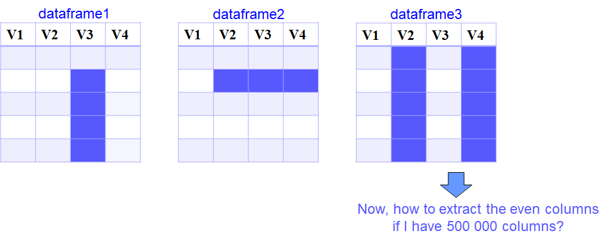

### **III.4. - Adding variables/columns to a dataframe:**

- **adding a column:** creating a new vector with characters and including it in the dataframe
1. either you add one vector at a time:

```r
# cell 73
d1
d1$new <- 1:2
d1
```

A data.frame: 2 × 2

| V1 <int> | V2 <int> |
| --- | --- |
| 1 | 10 |
| 2 | 11 |

A data.frame: 2 × 3

| V1 <int> | V2 <int> | new <int> |
| --- | --- | --- |
| 1 | 10 | 1 |
| 2 | 11 | 2 |

Here is another example to add a colum "sex" to the dataframe myDataf using a vector called "sex". I changed the name of the vector but you could keep the same name!

```r
# cell 74
gender <- c("Man", "Man", "Woman", "Woman", "Man", "Woman")
print(gender)
myDataf$sex <- gender
print(myDataf$sex)
myDataf
str(myDataf)
```

```
[1] "Man"   "Man"   "Woman" "Woman" "Man"   "Woman"
[1] "Man"   "Man"   "Woman" "Woman" "Man"   "Woman"
```

A data.frame: 6 × 4

|  | weight <int> | size <dbl> | bmi <dbl> | sex <chr> |
| --- | --- | --- | --- | --- |
| Fabien | 60 | 1.75 | 19.59184 | Man |
| Pierre | 72 | 1.80 | 22.22222 | Man |
| Sandrine | 57 | 1.65 | 20.93664 | Woman |
| Claire | 90 | 1.90 | 24.93075 | Woman |
| Bruno | 95 | 1.74 | 31.37799 | Man |
| Delphine | 72 | 1.91 | 19.73630 | Woman |

```
'data.frame':	6 obs. of  4 variables:
 $ weight: int  60 72 57 90 95 72
 $ size  : num  1.75 1.8 1.65 1.9 1.74 1.91
 $ bmi   : num  19.6 22.2 20.9 24.9 31.4 ...
 $ sex   : chr  "Man" "Man" "Woman" "Woman" ...
```

2. or add several vectors or several columns from another dataframe at once using `data.frame()`:

```r
# cell 75
d3 <-  data.frame(d1, d2)
d3
```

A data.frame: 2 × 6

| V1 <int> | V2 <int> | new <int> | V1.1 <lgl> | V2.1 <lgl> | V3 <lgl> |
| --- | --- | --- | --- | --- | --- |
| 1 | 10 | 1 | NA | NA | NA |
| 2 | 11 | 2 | NA | NA | NA |

**Caution:** You could also use **cbind()** but it is at risk as cbind() is rather a function for matrices. If you use it for dataframes, it will keep the data types only if you combine several variables of both dataframes. If you take only one variable from a dataframe, cbind() will convert it as a vector with a possible risk of coercion and of factorisation in versions of R < 4.

- **adding a row**: We do generally add columns that correspond to variables. In case you reallu want to add a row, this is achiveable by the function `rbind` which creates a matrix and you need to convert into a dataframe.

**Caution:** But it is extremly dangereous as your new row might modify the type of the values within columns/variables..

```r
# cell 76
d3 <- as.data.frame(rbind(d3, rep("toto", 6)))
d3
str(d3)
```

A data.frame: 3 × 6

| V1 <chr> | V2 <chr> | new <chr> | V1.1 <chr> | V2.1 <chr> | V3 <chr> |
| --- | --- | --- | --- | --- | --- |
| 1 | 10 | 1 | NA | NA | NA |
| 2 | 11 | 2 | NA | NA | NA |
| toto | toto | toto | toto | toto | toto |

```
'data.frame':	3 obs. of  6 variables:
 $ V1  : chr  "1" "2" "toto"
 $ V2  : chr  "10" "11" "toto"
 $ new : chr  "1" "2" "toto"
 $ V1.1: chr  NA NA "toto"
 $ V2.1: chr  NA NA "toto"
 $ V3  : chr  NA NA "toto"
```

### **III.5. - Subsetting a dataframe**

#### **a. The function `which()` returns the index of what is TRUE in a tested condition:**

```r
# cell 77
print(which ( myDataf$sex == "Woman") )
```

```
[1] 3 4 6
```

Here, we obtain a vector where 3, 4 and 6 corrrespond to the positions or indexes (1-based) of the occurence "Woman" in the vector/variable myDataf$sex. We can the use this vector as usual in a dataframe before the "," to select the corresponding rows.

```r
# cell 78
myDataf [ which ( myDataf$sex == "Woman") , ]
```

A data.frame: 3 × 4

|  | weight <int> | size <dbl> | bmi <dbl> | sex <chr> |
| --- | --- | --- | --- | --- |
| Sandrine | 57 | 1.65 | 20.93664 | Woman |
| Claire | 90 | 1.90 | 24.93075 | Woman |
| Delphine | 72 | 1.91 | 19.73630 | Woman |

```r
# cell 79
str(myDataf [ which ( myDataf$sex == "Woman") , ])
```

```
'data.frame':	3 obs. of  4 variables:
 $ weight: int  57 90 72
 $ size  : num  1.65 1.9 1.91
 $ bmi   : num  20.9 24.9 19.7
 $ sex   : chr  "Woman" "Woman" "Woman"
```

Instead of "==" one can use ̀`!=` for "is different" to detect what does not match.

```r
# cell 80
print(which ( myDataf$sex != "Man"))
```

```
[1] 3 4 6
```

Abother method would be to add `!` for "not" before the test, to get the complementary result:

```r
# cell 81
print(which (! myDataf$sex == "Man"))
```

```
[1] 3 4 6
```

**Caution:** What happens if you do not use `which()`?

Lets' make a copy of our dataframe and replace the gender of Claire by a missing value:

```r
# cell 82
myDataf2 <- myDataf
myDataf2["Claire", "sex"] <- NA
myDataf2
```

A data.frame: 6 × 4

|  | weight <int> | size <dbl> | bmi <dbl> | sex <chr> |
| --- | --- | --- | --- | --- |
| Fabien | 60 | 1.75 | 19.59184 | Man |
| Pierre | 72 | 1.80 | 22.22222 | Man |
| Sandrine | 57 | 1.65 | 20.93664 | Woman |
| Claire | 90 | 1.90 | 24.93075 | NA |
| Bruno | 95 | 1.74 | 31.37799 | Man |
| Delphine | 72 | 1.91 | 19.73630 | Woman |

and rerun the same command as above without which() on the new myDataf2:

```r
# cell 83
myDataf2[myDataf2$sex == "Woman",]
```

A data.frame: 3 × 4

|  | weight <int> | size <dbl> | bmi <dbl> | sex <chr> |
| --- | --- | --- | --- | --- |
| Sandrine | 57 | 1.65 | 20.93664 | Woman |
| NA | NA | NA | NA | NA |
| Delphine | 72 | 1.91 | 19.73630 | Woman |

```r
# cell 84
myDataf2[which(myDataf2$sex == "Woman"),]
```

A data.frame: 2 × 4

|  | weight <int> | size <dbl> | bmi <dbl> | sex <chr> |
| --- | --- | --- | --- | --- |
| Sandrine | 57 | 1.65 | 20.93664 | Woman |
| Delphine | 72 | 1.91 | 19.73630 | Woman |

**Caution:** If you have missing data and you forget to use which(), you will also return them. **=> Always use which()**

#### **b. One can also search for a pattern with `grep()`:**

It returns the index of what matches, even partially.

```r
# cell 85
print(grep("Wom", myDataf$sex))
```

```
[1] 3 4 6
```

```r
# cell 86
print(grep("Woman", myDataf$sex))
```

```
[1] 3 4 6
```

```r
# cell 87
myDataf [grep("Woman", myDataf$sex), ]
```

A data.frame: 3 × 4

|  | weight <int> | size <dbl> | bmi <dbl> | sex <chr> |
| --- | --- | --- | --- | --- |
| Sandrine | 57 | 1.65 | 20.93664 | Woman |
| Claire | 90 | 1.90 | 24.93075 | Woman |
| Delphine | 72 | 1.91 | 19.73630 | Woman |

```r
# cell 88
print(grep("a", row.names(myDataf)))
```

```
[1] 1 3 4
```

```r
# cell 89
myDataf [grep("a", row.names(myDataf)),]
```

A data.frame: 3 × 4

|  | weight <int> | size <dbl> | bmi <dbl> | sex <chr> |
| --- | --- | --- | --- | --- |
| Fabien | 60 | 1.75 | 19.59184 | Man |
| Sandrine | 57 | 1.65 | 20.93664 | Woman |
| Claire | 90 | 1.90 | 24.93075 | Woman |

#### **c. The function `subset()` is even simpler than `which()`:**

Just enter the dataframe as first argument, and the variable without "quotes" on which you do the filtering followed by the condition.

```r
# cell 90
WomenDataf <- subset(myDataf, gender== "Woman")
WomenDataf
```

A data.frame: 3 × 4

|  | weight <int> | size <dbl> | bmi <dbl> | sex <chr> |
| --- | --- | --- | --- | --- |
| Sandrine | 57 | 1.65 | 20.93664 | Woman |
| Claire | 90 | 1.90 | 24.93075 | Woman |
| Delphine | 72 | 1.91 | 19.73630 | Woman |

#### **d. You can even combine conditions:**

- logical: `&` = AND, `|` = OR, `!` = not
- comparisons: `==` , `!=` for diffferent, `>`, `<`, `>=`, `>=`
- "is an element of" a vector using `%in%`

```r
# cell 91
filteredData <- myDataf [ which ( myDataf$sex == "Woman" & myDataf$weight < 80 & myDataf$bmi > 20), ]
filteredData
```

A data.frame: 1 × 4

|  | weight <int> | size <dbl> | bmi <dbl> | sex <chr> |
| --- | --- | --- | --- | --- |
| Sandrine | 57 | 1.65 | 20.93664 | Woman |

```r
# cell 92
subset( myDataf, sex == "Woman" & weight < 80 & bmi > 20)
```

A data.frame: 1 × 4

|  | weight <int> | size <dbl> | bmi <dbl> | sex <chr> |
| --- | --- | --- | --- | --- |
| Sandrine | 57 | 1.65 | 20.93664 | Woman |

**Success:** Well done! You now know all the main functions to create and manipulate dataframes.

## **IV - Plots**

R is a fanstatic tool to draw nice graphs: https://r-graph-gallery.com/ and https://www.data-to-viz.com/. A great package **ggplot2** allows to draw the nicest plots.

We could spend several sessions on the topic but let's have a quick view of what can be done with **R base** commands on our dataframe.

#### **a. scatter plot with the function `plot()`**

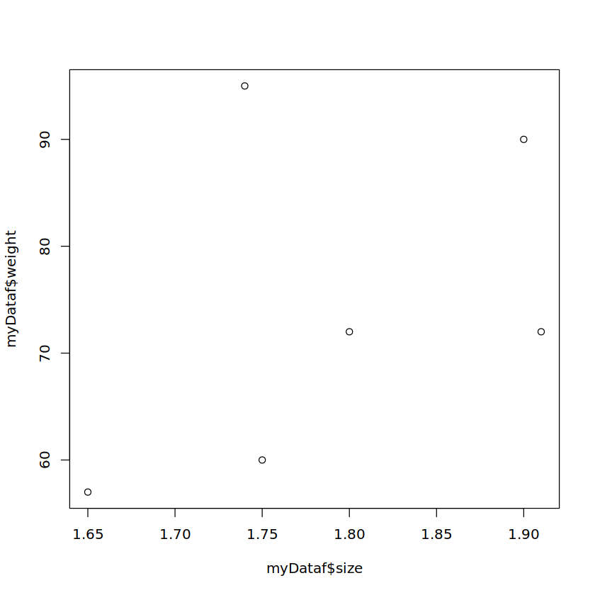

```r
# cell 93
plot(myDataf$weight ~ myDataf$size)
```

#### **b. Representation of quantitative data distribution**

- as a boxplot with `boxplot()`:

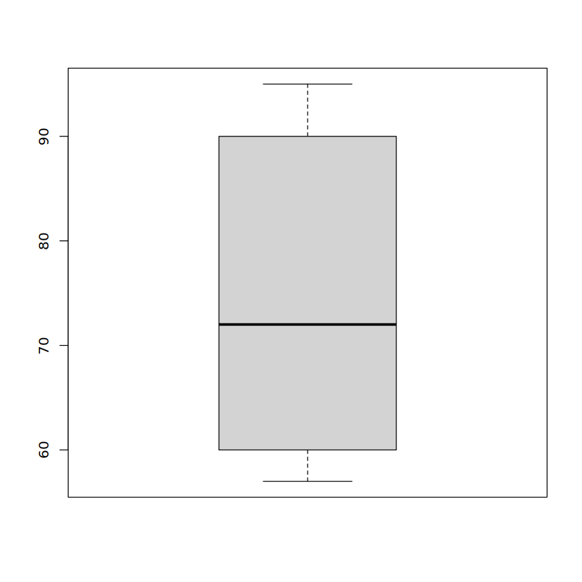

```r
# cell 94
boxplot(myDataf$weight)
```

or using `~` to display boxplots on the same plot depending on a categorical variable:

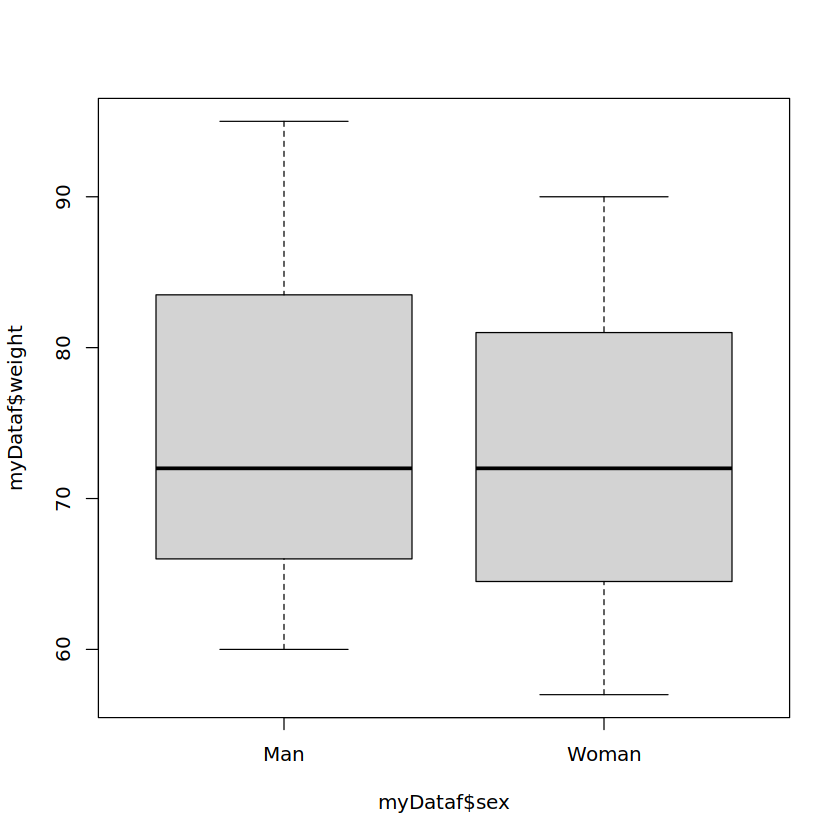

```r
# cell 95
boxplot(myDataf$weight ~ myDataf$sex)
```

- as a histogram with `hist()`:

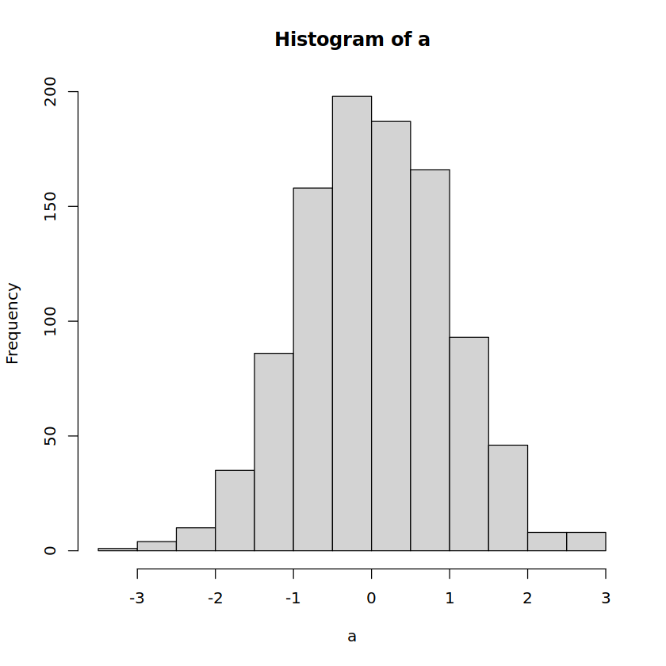

```r
# cell 96
a <- rnorm(1000) # to sample 1000 values from a normal distribution of mean 0 and standard deviation 1
hist(a, breaks=20) # the argument breaks is used to specify the number of intervals
```

- **customize graphs**

**Graphs have three-level functions:**

1. **primary graph functions** like `plot()`, `boxplot` and `hist()` to display the most principal graphs in R
2. **secondary graph functions** to complement an existing plot like `points()`, `lines()`, `legend()` or `title()` to display the most principal graphs in R. In a notebook, use them in the same cell.
3. **graphical parameters** to modify the plots display:
   - either as options of the primary and secondary functions
   - or permanetly with the `par()` function before plotting the graph.

Below is an example using primary and secondary functions:

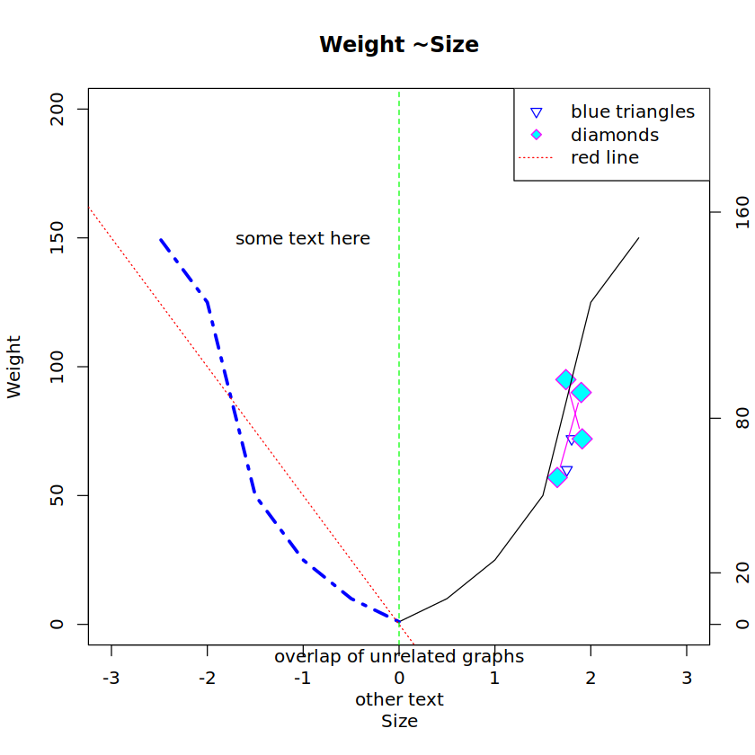

```r
# cell 97
plot(myDataf$weight ~ myDataf$size,
     main = "Weight ~Size",
     xlim = c(-3,3),
     ylim = c(0,200),
     type = "n",
     xlab = "Size",
     ylab = "Weight")
points(myDataf$weight[1:2] ~ myDataf$size[1:2],
       pch = 6,
       col = "blue")
points(myDataf[3:6,"weight"] ~ myDataf$size[3:6],
       type = "b",
       pch = 23,
       col = "magenta",
       bg = "cyan",
       cex = 2)
points(seq(0, 2.5, 0.5),
       c(1, 10, 25, 50, 125, 150),
       type = "l")
lines(-seq(0, 2.5, 0.5),
      c(1, 10, 25, 50, 125, 150),
      lty = "dotdash",
      col = "blue",
      lwd = 3)
abline(0, -50,
       lty = 3,
       col = "red")
abline(v = 0,
       lty = 2,
       col = "green")

mtext("overlap of unrelated graphs",
      side = 1)
mtext("other text",
      side = 1,
      line = 2)
text(-1, 150,
     "some text here")
axis(side = 4,
     labels = c(0, 20, 80, 160),
     at = c(0, 20, 80, 160),
     tick = TRUE)
legend("topright",
       c("blue triangles", "diamonds", "red line"),
       pch = c(6, 23, NA),
       col = c("blue", "magenta", "red"),
       pt.bg = c("transparent", "cyan", "transparent"),
       lty = c(0,0,3))
```

- **saving graphs**

Save figures in different formats with the appropriate function (by default in the working directory)

| function | extension file |
| --- | --- |
| bmp() | .bmp |
| jpeg() | .jpeg |
| tiff() | .tiff |
| png() | .png |
| postscript() | .eps |
| pdf() | .pdf |

***Three steps***

1. Type the function with the name of the saved file as an argument with the correct extension. Other arguments like « width » and « height » to specify dimensions.
2. Do your plot -> it is directed to the file and not displayed in the graphical window within R
3. Close the graph by typing the `dev.off()` function

> Specific case for `pdf()`: you may save each figure at a time or all several (all) figures generated with all the command lines entered between `pdf()` and `dev.off()`.

## **V - Statistics with R**

R is a dedicated language to perform statistics including descriptive statistics and statistical tests.

- for descriptive statistics you may use `summary()` function:

```r
# cell 98
summary(myDataf)
```

```
     weight           size            bmi            sex
 Min.   :57.00   Min.   :1.650   Min.   :19.59   Length:6
 1st Qu.:63.00   1st Qu.:1.742   1st Qu.:20.04   Class :character
 Median :72.00   Median :1.775   Median :21.58   Mode  :character
 Mean   :74.33   Mean   :1.792   Mean   :23.13
 3rd Qu.:85.50   3rd Qu.:1.875   3rd Qu.:24.25
 Max.   :95.00   Max.   :1.910   Max.   :31.38
```

- for statistical tests

Let's start with a t test with the function `t.test` that compares means of quantitative variable between 2 groups.

```r
# cell 99
t.test(myDataf$weight ~ myDataf$sex)
```

```
	Welch Two Sample t-test

data:  myDataf$weight by myDataf$sex
t = 0.19026, df = 3.9785, p-value = 0.8584
alternative hypothesis: true difference in means between group Man and group Woman is not equal to 0
95 percent confidence interval:
 -36.33073  41.66406
sample estimates:
  mean in group Man mean in group Woman
           75.66667            73.00000
```

**To interpret the test, look at the p-value** If it is below the alpha risk, then you can reject the null hypothesis

In the example above, it is not significant at 5%: the null hypothesis could not be rejected.

Let's now perform a Chi square test with `chisq.test()` that compares distributions of qualitative variables.

For the example, lets consider a contingency table with counts of genotypes obtained in 2 groups, one of patients and one of controls.

| genotype | cases | controls |
| --- | --- | --- |
| 0/0 | 188 | 94 |
| 1/0 (or 0/1) | 133 | 92 |
| 1/1 | 24 | 30 |

```r
# cell 100
cases_controls <- data.frame("genotype" = c("0/0", "1/0 (or 0/1)", "1/1"),
                             "cases" = c(188,133,24),
                             "controls" = c(94,92,30))
```

```r
# cell 101
cases_controls
```

A data.frame: 3 × 3

| genotype <chr> | cases <dbl> | controls <dbl> |
| --- | --- | --- |
| 0/0 | 188 | 94 |
| 1/0 (or 0/1) | 133 | 92 |
| 1/1 | 24 | 30 |

We can compute the observed frequencies with the function `proportions`...

```r
# cell 102
proportions(as.matrix(cases_controls[,2:3]),2)
```

A matrix: 3 × 2 of type dbl

| cases | controls |
| --- | --- |
| 0.54492754 | 0.4351852 |
| 0.38550725 | 0.4259259 |
| 0.06956522 | 0.1388889 |

...and display these proportions in a stacked barplot:

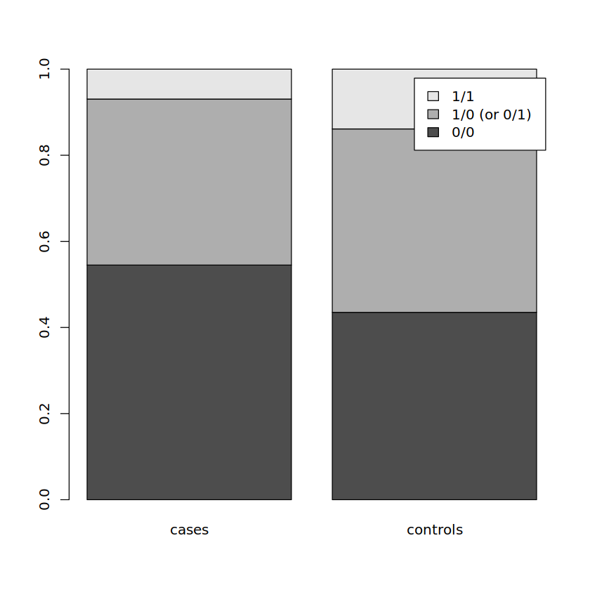

```r
# cell 103
barplot(proportions(as.matrix(cases_controls[,2:3]),2),
        beside = FALSE,
        legend = cases_controls$genotype)
```

Let's now test whether these proportions differ between cases and controls with a Chi square test:

```r
# cell 104
chisq.test(cases_controls[, 2:3])
```

```
	Pearson's Chi-squared test

data:  cases_controls[, 2:3]
X-squared = 10.356, df = 2, p-value = 0.005641
```

This time the pvalue is belwo 5%, wa can reject the null hypothesis of equal frequencies.

**Success:** Well done! You have seen how to draw basic plots and run simple statistics with R base.

## Useful commands

- `CTRL`+`S` : save notebook
- `CTRL`+`ENTER` : Run Cell
- `SHIFT`+`ENTER` : Run Cell and Select Next
- `ALT`+`ENTER` : Run Cell and Insert Below
- `ESC`+`y` : Change to *Code* Cell Type
- `ESC`+`m` : Change to *Markdown* Cell Type
- `ESC`+`r` : Change to *Raw* Cell Type
- `ESC`+`a` : Create Cell Above
- `ESC`+`b` : Create Cell Below

To make nice html reports with markdown: [html visualization tool 1](https://dillinger.io/) or [html visualization tool 2](https://stackedit.io/app#), [to draw nice tables](https://www.tablesgenerator.com/markdown_tables), and the [Ultimate guide](https://medium.com/analytics-vidhya/the-ultimate-markdown-guide-for-jupyter-notebook-d5e5abf728fd).  
Further reading on JupyterLab notebooks: [Jupyter Lab documentation](https://jupyterlab.readthedocs.io/en/latest/user/notebook.html).

*[Last version revised on 31/03/2023 by @CVandiedonck]*